# Importing Spreadsheet-Like Data

RAdelaide 2025

Author

Affiliation

Dr Stevie Pederson

Black Ochre Data Labs  
The Kids Research Institute Australia

Published

July 8, 2025

# Importing Data

Now that we’ve spent some time exploring the penguins dataset, how would we import this into R from a spreadsheet?

## Data In R

- Working with data in R is **very different** to Excel
- Can have complicated structures or be simple (e.g. `x <- 1:5`)
- Spreadsheet-like data is very common
- Is known as a `data.frame`
  - A common variant is known as a `tibble`
  - These were originally called `tbl_df` objects referring to SQL tables
  - Is just a `data.frame` with some convenience features

## Data In R

- We import the data as an `R` object
  - All analysis is performed on the `R` object
  - **Almost never** modify the source file
- Once data is imported the source file is no longer involved

## Common File Types

- Probably worth noting the many European countries use the comma as a decimal point
- Can also separate using a semi-colon
- Windows hiding file extensions as a fundamentally dumb idea
- Excel files (`xls`/`xlsx`) have one or more spreadsheets
  - Can import one sheet at a time using `library(readxl)`
- Comma-separated Values (`.csv`)
  - Plain text file
  - Column-style data with commas delimiting the columns
- Resemble a single spreadsheet but:
  - No formatting
  - No formulas $\implies$ only values
  - No graphs/figures

## Common File Types

- Tab-separated Values (`.tsv`)
  - Like a `.csv` but with tabs separating columns
- Sometimes see files saved as `.txt`
  - Can be anything $\implies$ need to check

## Importing Data

When importing data into `R`:

- *Cell formatting will be ignored by R*
- *Plots will also be ignored*
- Blank rows/columns are not fatal, just annoying
- Mixtures of numbers and text in a column
  - `data.frame` columns contain all the same type of value
- Deleted cells are sometimes imported as blank rows/columns
- Comma-separated or tab-separated files are often favoured for `R`
  - i.e. plain text, or *just the data*
- Can also import data from Stata, SPSS or other statistical languages

## Other Common Excel Issues

If we’re not careful:

1. Excel thinks everything is a date:
   - Septin genes are now officially named *SEPTIN2* etc (not *SEPT2*)
   - Fractions are also **not** dates…
2. Excel will remove leading zeroes (e.g. phone numbers, catalog ids)
3. No record of any steps we’ve performed by clicking on something
- Very common sources of broken data $\implies$ may need fixing
- ’000s of publications with dates for gene names in results

Mention my former collaborator who would often have completely different results in the ones I’d send him - To sort by p-value, he’d select the p-value column & sort (just that column) - There was no record of this. Only discovered by sitting down with him

## Preparation

1. `File` > `New File` > `R Script` (Or `Ctrl+Shift+N`)
2. Save as `ImportPenguins.R`

## Preparation

1. Download the file `data.zip` from the workshop homepage
2. Place in your directory `RAdelaide25`
3. `Extract to here` which should create a folder named `data`

**Make sure your files are in `data` not in `data/data`**

4. This should contain all files for the workshop
5. Navigate to the `data` directory using the `Files` pane

(You should see `penguins.csv` in `data`)

# Import Using the GUI

## Importing Data

1. Preview the file `penguins.csv` by clicking on it (`View File`)
   - Try in Excel if you prefer, but **DO NOT(!!!)** save anything from Excel
- This is a common dataset as a simple `.csv` file
- This type of data is very easy to manage in `R`
  - Plain text with comma delimiters
  - Simple column structure with column names
  - No blank rows at the top or separating sub-tables
  - No blank columns
  - No rownames

## Using the GUI To Load Data

Click on `penguins.csv`, choose `Import Dataset` then **stop**! 🛑

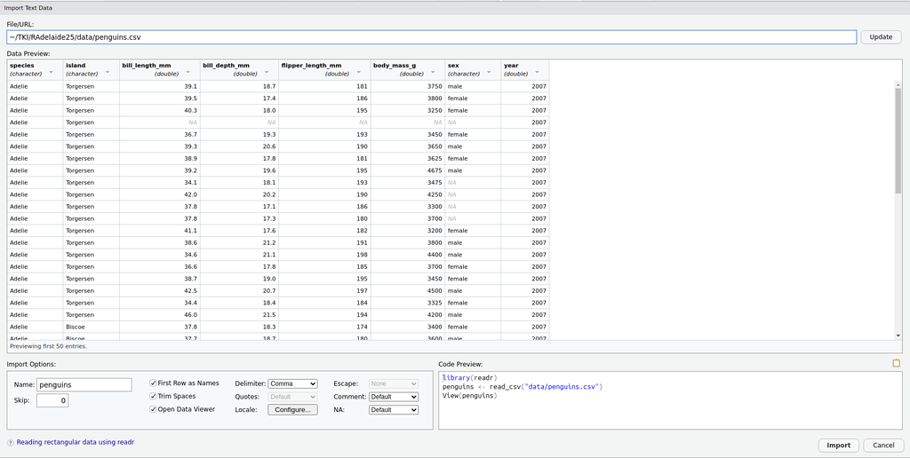

(Click `Update` if you don’t see this)

## The Preview Window

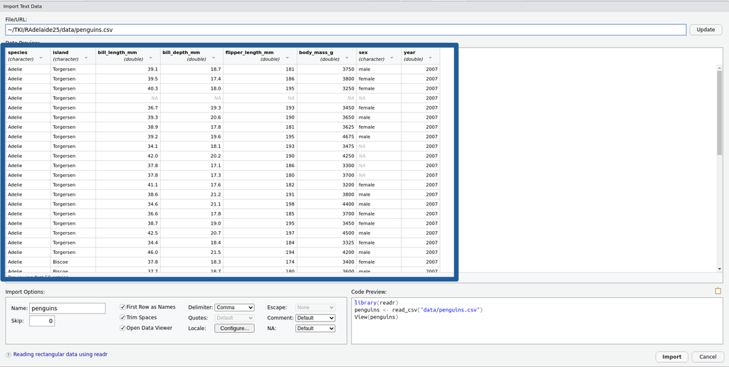

We have a preview of the data

- This is another preview of the data before we import it
- We can see all the expected columns
- Notice the types of values are provided under the column names

## The Preview Window

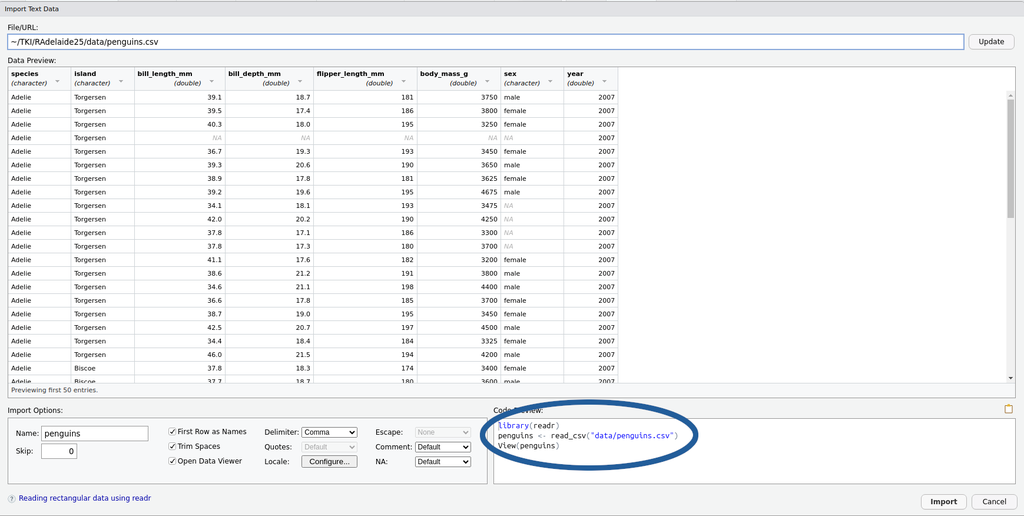

We also have a preview of the code we’re about to execute

## The Preview Window

1. Select and copy all the code in the `Code Preview` Box
   - We’ll paste this somewhere in a minute…
2. Click `Import`
3. Magic happens!!!
   - Ignore the coloured text. This is just ‘helpful information’

*Now paste the copied code at the top of your script*

## What just happened?

The code we copied has 3 lines:

```r
library(readr)
penguins <- read_csv("data/penguins.csv")
View(penguins)
```

- `library(readr)` loads the package `readr`
  - Packages are collections (i.e. libraries) of related functions
  - All `readr` functions are about importing data
- `readr` contains the function `read_csv()`
- `read_csv()` tells R what to do with a csv file

## What just happened?

The code we copied has 3 lines:

```r
library(readr)
penguins <- read_csv("data/penguins.csv")
View(penguins)
```

- This line actually loads the data into your `R Environment`
- It creates an object named `penguins` by using the file name (penguins.csv)
- Can change this name if we wish

## What just happened?

The code we copied has 3 lines:

```r
library(readr)
penguins <- read_csv("data/penguins.csv")
View(penguins)
```

- Opens a preview in a familiar `Excel-like` format
  - I personally never use this

Close the preview by clicking the cross

## What just happened?

- We have just loaded data using the default settings of `read_csv()`
- The object `penguins` is now in our `R Environment`
  - The original file remains on our HDD **without modification**!!!
- The code is saved in our script  
  $\implies$ **we don’t need the GUI for this operation again!**

## Let’s Demonstrate

Realistically we only need to preview it the first time. Having that preview open every time actually ends up being really annoying

1. In the `Environment Tab` click the broom icon 🧹
   - This will delete everything from your `R Environment`
   - It won’t unload the packages
2. Highlight the code we’ve just pasted and click `Run`
   - Reloading the packages won’t hurt
3. Check the `Environment Tab` again and `penguins` is back

You can delete the line `View(penguins)`

## Our First R Script

- This is now our first R script
  - An R script is a plain text file
  - No objects are stored
- Individual lines can be run using `Ctrl/Cmd + Enter`
- Can select multiple lines & run

## Our First R Script

- Insert a new line before `library(readr)` then type

```r
## Load packages first
```

- This is a comment $\implies$ no executable code
  - Communicates to “future” you what you’re doing
  - Only needs a single `#` to be a comment

## Our First R Script

- Insert a line after `library(readr)` then enter

```r
## Now load the file "penguins.csv"
## Taken from https://allisonhorst.github.io/palmerpenguins/index.html
```

# Data Frame Objects

## Data Frame Objects

- The object `penguins` is known as a `data.frame`
  - Very similar to an SQL table
- `R` equivalent to a spreadsheet
  - **Must** have column names
  - row names becoming less common (sometimes just the row numbers)
  - Missing values (blank cells) are usually filled with `NA`

## Data Frame Objects

Instead of `View()` $\implies$ preview by typing the object name

```r
penguins
```

```
# A tibble: 344 × 8
   species island    bill_length_mm bill_depth_mm flipper_length_mm body_mass_g
   <chr>   <chr>              <dbl>         <dbl>             <dbl>       <dbl>
 1 Adelie  Torgersen           39.1          18.7               181        3750
 2 Adelie  Torgersen           39.5          17.4               186        3800
 3 Adelie  Torgersen           40.3          18                 195        3250
 4 Adelie  Torgersen           NA            NA                  NA          NA
 5 Adelie  Torgersen           36.7          19.3               193        3450
 6 Adelie  Torgersen           39.3          20.6               190        3650
 7 Adelie  Torgersen           38.9          17.8               181        3625
 8 Adelie  Torgersen           39.2          19.6               195        4675
 9 Adelie  Torgersen           34.1          18.1               193        3475
10 Adelie  Torgersen           42            20.2               190        4250
# ℹ 334 more rows
# ℹ 2 more variables: sex <chr>, year <dbl>
```

## Data Frame Objects

I personally find this more informative than `View()`

## Tibble Objects

- `readr` uses a variant called a `tbl_df` or `tbl` (pronounced tibble)
  - A `data.frame` with convenient features
  - Similar to a SQL table
  - Can *only have row numbers for row names*
  - Is a foundational structure in the `tidyverse`

## The Tidyverse

- The `tidyverse` is a collection of *thematically-linked* packages
  - Produced by developers from RStudio/Posit
  - Often referred to as *tidy*-programming or similar
- Calling `library(tidyverse)` loads multiple key packages
  - `readr` is one of these $\implies$ usually just load the tidyverse
  - Will load `dplyr`, `tidyr`, `readr`, `ggplot2` + others

## The Tidyverse

1. Replace `library(readr)` with `library(tidyverse)`
2. Execute this line
- This will load all core packages from the tidyverse
- Reloading a package has no effect (is ignored)

## Previewing Objects

- Some additional ways to inspect tibbles are:

```r
head(penguins)
glimpse(penguins)
```

- `glimpse` is loaded with `library(tidyverse)`

**What were the differences between each method?**

# Functions

## Functions in `R`

```r
head(penguins)
glimpse(penguins)
```

- Here we have called the functions `head()` and `glimpse()`
  - They were both executed on the object `penguins`
- Call the help page for `head()`

```r
?head
```

(if you get multiple options, choose the one from `utils`)

## Functions in `R`

- The key place to look at is

```r
head(x, ...)
## Default S3 method:
head(x, n = 6L, ...)
```

- there are two arguments to `head()` $\implies$ `x` and `n`
  - `x` has no default value $\implies$ **we need to provide something**
  - `n = 6L` means `n` has a default value of 6 (L $\implies$ `integer`)

Execute `head()` to show the error!!!

## Functions in `R`

Lower down the page you’ll see

**Arguments**

`x` an object  
`n` an integer vector of length up to dim(x) (or 1, for non-dimensioned objects). *Blah, blah, blah…*

- Some of the rest is technical detail (can sometimes be *very helpful*)

## Function Arguments

- `head()` prints the *first part* of an object
- Useful for very large objects (e.g. if we had 1000 guinea penguins)
- We can change the number of rows shown to us

```r
head(penguins, 4)
```

```
# A tibble: 4 × 8
  species island    bill_length_mm bill_depth_mm flipper_length_mm body_mass_g
  <chr>   <chr>              <dbl>         <dbl>             <dbl>       <dbl>
1 Adelie  Torgersen           39.1          18.7               181        3750
2 Adelie  Torgersen           39.5          17.4               186        3800
3 Adelie  Torgersen           40.3          18                 195        3250
4 Adelie  Torgersen           NA            NA                  NA          NA
# ℹ 2 more variables: sex <chr>, year <dbl>
```

## Function Arguments

- If passing values *in order* $\implies$ no need for names

```r
head(penguins, 4)
```

```
# A tibble: 4 × 8
  species island    bill_length_mm bill_depth_mm flipper_length_mm body_mass_g
  <chr>   <chr>              <dbl>         <dbl>             <dbl>       <dbl>
1 Adelie  Torgersen           39.1          18.7               181        3750
2 Adelie  Torgersen           39.5          17.4               186        3800
3 Adelie  Torgersen           40.3          18                 195        3250
4 Adelie  Torgersen           NA            NA                  NA          NA
# ℹ 2 more variables: sex <chr>, year <dbl>
```

```r
head(x = penguins, n = 4)
```

```
# A tibble: 4 × 8
  species island    bill_length_mm bill_depth_mm flipper_length_mm body_mass_g
  <chr>   <chr>              <dbl>         <dbl>             <dbl>       <dbl>
1 Adelie  Torgersen           39.1          18.7               181        3750
2 Adelie  Torgersen           39.5          17.4               186        3800
3 Adelie  Torgersen           40.3          18                 195        3250
4 Adelie  Torgersen           NA            NA                  NA          NA
# ℹ 2 more variables: sex <chr>, year <dbl>
```

## Function Arguments

- If we explicitly name arguments $\implies$ can pass *in any order*

```r
head(n = 4, x = penguins)
```

```
# A tibble: 4 × 8
  species island    bill_length_mm bill_depth_mm flipper_length_mm body_mass_g
  <chr>   <chr>              <dbl>         <dbl>             <dbl>       <dbl>
1 Adelie  Torgersen           39.1          18.7               181        3750
2 Adelie  Torgersen           39.5          17.4               186        3800
3 Adelie  Torgersen           40.3          18                 195        3250
4 Adelie  Torgersen           NA            NA                  NA          NA
# ℹ 2 more variables: sex <chr>, year <dbl>
```

## Function Arguments

- Check the help page for `glimpse()`
  - This is from the package `pillar`
- Try changing the `width` argument to see what happens
  - Default value auto-detects screen width

## Understanding `read_csv()`

- Earlier we called the `R` function `read_csv()`
- Check the help page

```r
?read_csv
```

- We have four functions shown but stick to `read_csv()`

## Understanding `read_csv()`

```r
read_csv(
  file,
  col_names = TRUE, col_types = NULL, col_select = NULL,
  id = NULL, locale = default_locale(),
  na = c("", "NA"), quoted_na = TRUE,
  quote = "\"", comment = "",
  trim_ws = TRUE,
  skip = 0, n_max = Inf,
  guess_max = min(1000, n_max),
  name_repair = "unique",
  num_threads = readr_threads(),
  progress = show_progress(),
  show_col_types = should_show_types(),
  skip_empty_rows = TRUE,
  lazy = should_read_lazy()
)
```

- This function has *way too many arguments* (`file`, `col_names` etc.)
- Most have default values given  
  `col_names = TRUE` $\implies$ column names assumed as the first row
- Ask which arguments have default before moving to the fragment…

## Understanding `read_csv()`

All `arguments` were defined somewhere in the GUI.

1. Open the GUI Preview by clicking on the file again
2. Uncheck the `First Row as Names` check-box
- *What happened to the code?*
- *How did the columns change?*

Try clicking/unclicking a few more & try understand the consequences

## Understanding `read_csv()`

- Column types can also be set using shorthand
  - “ccnnnncn” is a mix of character & number columns

```r
penguins <- read_csv("data/penguins.csv", col_types = "ccnnnncn")
```

- Changing one of the character columns to “n” will lead to `NA`s
- Changing the numeric column to character would mean … ?

# Closing Comments

## `read_csv()` Vs `read.csv()`

- `RStudio` now uses `read_csv()` from `readr` **by default**
- You will often see `read.csv()` (from `utils`) in older scripts
- The newer (`readr`) version is:
  - slightly faster
  - **more user-friendly**
  - handles large files more efficiently via indexing
  - gives informative messages
- Earlier functions in `utils` are `read.*()` (csv, delim etc.)
- `readr` has the functions `read_*()` (csv, tsv, delim etc.)
- I *always* use the newer ones

## Reading Help Pages: Bonus Slide

- The bottom three functions are simplified wrappers to `read_delim()`
- `read_csv()` calls `read_delim()` using `delim = ","`
- `read_csv2()` calls `read_delim()` using `delim = ";"`
- `read_tsv()` calls `read_delim()` using `delim = "\t"`

**What function would we call for *space-delimited* files?**

## Loading Excel Files

- The package `readxl` is for loading `.xls` and `xlsx` files.
- Not part of the core tidyverse but **very** compatible

```r
library(readxl)
```

- The main function is `read_excel()`

```r
?read_excel
```

## Loading Excel Files

- This file contains multiple sheets

```r
excel_sheets("data/RealTimeData.xlsx")
```

```
[1] "Sheet1" "Sheet2" "Sheet3"
```

I found this file after a random Google search for RT-PCR and Excel about 10 years ago. I didn’t keep track of who created it…

- Once again we can click on the file $\implies$ `Import Dataset`
  - `Sheet1` looks pretty simple
  - First column has no name
- Use the drop-down menu to look at the `Sheet2` & `Sheet3`
- We’ll learn how to manage these as challenges later